# CAPSTONE PROJECT - SOCIAL MEDIA TOURISM

## Problem Statement

An aviation company that provides domestic as well as international trips to the customers now wants to apply a targeted approach instead of reaching out to each of the customers. This time they want to do it digitally instead of tele-calling. Hence they have collaborated with a social networking platform, so they can learn the digital and social behavior of the customers and provide the digital advertisement on the user page of the targeted customers who have a high propensity to take up the product. Propensity of buying tickets is different for different login devices. Hence, you have to create 2 models separately for Laptop and Mobile.

NOTE: Anything which is not a laptop can be considered as mobile phone usage.

NOTE: The advertisements on the digital platform are bit expensive, hence you need to be very accurate while creating the models.

### Importing Libraries and Checking the Data :-

```python
#Importing basic Libraries

import numpy as np,pandas as pd,seaborn as sns,matplotlib.pyplot as plt
%matplotlib inline

#to ignore warnings
import warnings
warnings.filterwarnings('ignore')
```

```python
#Loading the dataset

data = pd.read_csv(r'D:\SHUBHANK !\GL\My_Capstone_Project\Social Media Data for DSBA.csv')
```

### Exploring the Data :-

```python
#Reading the head of the dataset

data.head().T
```

|  | 0 | 1 | 2 | 3 | 4 |
| --- | --- | --- | --- | --- | --- |
| UserID | 1000001 | 1000002 | 1000003 | 1000004 | 1000005 |
| Taken_product | Yes | No | Yes | No | No |
| Yearly_avg_view_on_travel_page | 307.0 | 367.0 | 277.0 | 247.0 | 202.0 |
| preferred_device | iOS and Android | iOS | iOS and Android | iOS | iOS and Android |
| total_likes_on_outstation_checkin_given | 38570.0 | 9765.0 | 48055.0 | 48720.0 | 20685.0 |
| yearly_avg_Outstation_checkins | 1 | 1 | 1 | 1 | 1 |
| member_in_family | 2 | 1 | 2 | 4 | 1 |
| preferred_location_type | Financial | Financial | Other | Financial | Medical |
| Yearly_avg_comment_on_travel_page | 94.0 | 61.0 | 92.0 | 56.0 | 40.0 |
| total_likes_on_outofstation_checkin_received | 5993 | 5130 | 2090 | 2909 | 3468 |
| week_since_last_outstation_checkin | 8 | 1 | 6 | 1 | 9 |
| following_company_page | Yes | No | Yes | Yes | No |
| montly_avg_comment_on_company_page | 11 | 23 | 15 | 11 | 12 |
| working_flag | No | Yes | No | No | No |
| travelling_network_rating | 1 | 4 | 2 | 3 | 4 |
| Adult_flag | 0 | 1 | 0 | 0 | 1 |
| Daily_Avg_mins_spend_on_traveling_page | 8 | 10 | 7 | 8 | 6 |

```python
#Printing the shape and size of the dataset

print('Total Columns: ',data.shape[1])
print('Total Rows: ',data.shape[0])
print('\nSize of the data:',data.size)
```

```
Total Columns:  17
Total Rows:  11760

Size of the data: 199920
```

```python
#Let see all the names of the columns in the dataset

Column_names = [data.columns]

Column_names
```

```
[Index(['UserID', 'Taken_product', 'Yearly_avg_view_on_travel_page',
        'preferred_device', 'total_likes_on_outstation_checkin_given',
        'yearly_avg_Outstation_checkins', 'member_in_family',
        'preferred_location_type', 'Yearly_avg_comment_on_travel_page',
        'total_likes_on_outofstation_checkin_received',
        'week_since_last_outstation_checkin', 'following_company_page',
        'montly_avg_comment_on_company_page', 'working_flag',
        'travelling_network_rating', 'Adult_flag',
        'Daily_Avg_mins_spend_on_traveling_page'],
       dtype='object')]
```

### Renaming few of the columns for better readability and understanding:-

Replacing few long words in short abbreviations, like:

- Travel_page and Company_page are same, so replacing it with: CP
- Outstation or out of station are same, so replacing it with: OS
- Yearly_avg as: YA
- Daily_avg as: DA
- Preffered as: Pref
- Total_likes as: TL
- Monthly_avg as: MA

```python
data.rename({'Yearly_avg_view_on_travel_page': 'YA_view_on_CP',
             'preferred_device': 'Pref_device',
            'total_likes_on_outstation_checkin_given': 'TL_done_on_OS_checkin',
            'yearly_avg_Outstation_checkins' : 'YA_OS_checkin',
            'member_in_family' : 'Members_in_fam',
            'preferred_location_type' : 'Pref_loc_type',
            'Yearly_avg_comment_on_travel_page' : 'YA_comment_on_CP',
            'total_likes_on_outofstation_checkin_received' : 'TL_rec_on_OS_checkin',
            'week_since_last_outstation_checkin' : 'Week_since_last_OS_checkin',
            'following_company_page' : 'Following_CP',
            'working_flag' : 'Working_flag',
            'travelling_network_rating' : 'Travelling_network_rating',
            'montly_avg_comment_on_company_page':'MA_comment_on_CP',
            'Daily_Avg_mins_spend_on_traveling_page' : 'DA_mins_spend_on_CP'}, axis=1, inplace=True)
```

```python
#let us look at the basic information about the dataset

data.info()
```

```
<class 'pandas.core.frame.DataFrame'>
RangeIndex: 11760 entries, 0 to 11759
Data columns (total 17 columns):
 #   Column                      Non-Null Count  Dtype
---  ------                      --------------  -----
 0   UserID                      11760 non-null  int64
 1   Taken_product               11760 non-null  object
 2   YA_view_on_CP               11179 non-null  float64
 3   Pref_device                 11707 non-null  object
 4   TL_done_on_OS_checkin       11379 non-null  float64
 5   YA_OS_checkin               11685 non-null  object
 6   Members_in_fam              11760 non-null  object
 7   Pref_loc_type               11729 non-null  object
 8   YA_comment_on_CP            11554 non-null  float64
 9   TL_rec_on_OS_checkin        11760 non-null  int64
 10  Week_since_last_OS_checkin  11760 non-null  int64
 11  Following_CP                11657 non-null  object
 12  MA_comment_on_CP            11760 non-null  int64
 13  Working_flag                11760 non-null  object
 14  Travelling_network_rating   11760 non-null  int64
 15  Adult_flag                  11760 non-null  int64
 16  DA_mins_spend_on_CP         11760 non-null  int64
dtypes: float64(3), int64(7), object(7)
memory usage: 1.5+ MB
```

Null/Missing values are present in the data.

```python
# let us check how many missing values are there in those columns

data.isnull().sum()
```

```
UserID                          0
Taken_product                   0
YA_view_on_CP                 581
Pref_device                    53
TL_done_on_OS_checkin         381
YA_OS_checkin                  75
Members_in_fam                  0
Pref_loc_type                  31
YA_comment_on_CP              206
TL_rec_on_OS_checkin            0
Week_since_last_OS_checkin      0
Following_CP                  103
MA_comment_on_CP                0
Working_flag                    0
Travelling_network_rating       0
Adult_flag                      0
DA_mins_spend_on_CP             0
dtype: int64
```

```python
#Total count of the missing values

print('Total missing values:',data.isnull().sum().sum())
```

```
Total missing values: 1430
```

```python
#While checking, we've got 1430 total missing values in the dataset, which is around 12% of the total records
#So we decide not to do any random imputation because it may affect our model

#Lets just drop them all

data.dropna(inplace=True)
```

```python
#After dropping, let us check the null values again

data.isnull().sum()
```

```
UserID                        0
Taken_product                 0
YA_view_on_CP                 0
Pref_device                   0
TL_done_on_OS_checkin         0
YA_OS_checkin                 0
Members_in_fam                0
Pref_loc_type                 0
YA_comment_on_CP              0
TL_rec_on_OS_checkin          0
Week_since_last_OS_checkin    0
Following_CP                  0
MA_comment_on_CP              0
Working_flag                  0
Travelling_network_rating     0
Adult_flag                    0
DA_mins_spend_on_CP           0
dtype: int64
```

```python
# Check Duplicates: Before dropping the UserId column

duplicates = data.duplicated()
print('Number of duplicate rows = %d' % (duplicates.sum()))
```

```
Number of duplicate rows = 0
```

```python
#Description of the data and five number summary using describe function

pd.set_option('display.float_format', lambda x: '%.2f' % x) #Keeping the decimal points upto 2 places
data.describe().T
```

|  | count | mean | std | min | 25% | 50% | 75% | max |
| --- | --- | --- | --- | --- | --- | --- | --- | --- |
| UserID | 10456.00 | 1006283.35 | 3339.07 | 1000001.00 | 1003464.75 | 1006532.50 | 1009146.25 | 1011760.00 |
| YA_view_on_CP | 10456.00 | 281.27 | 68.27 | 35.00 | 232.00 | 271.00 | 325.00 | 464.00 |
| TL_done_on_OS_checkin | 10456.00 | 28156.85 | 14215.28 | 3570.00 | 16317.00 | 28175.00 | 40526.75 | 152465.00 |
| YA_comment_on_CP | 10456.00 | 75.15 | 23.20 | 3.00 | 57.00 | 75.00 | 93.00 | 685.00 |
| TL_rec_on_OS_checkin | 10456.00 | 6535.17 | 4706.53 | 1009.00 | 2946.75 | 4947.00 | 8396.50 | 20065.00 |
| Week_since_last_OS_checkin | 10456.00 | 3.21 | 2.61 | 0.00 | 1.00 | 3.00 | 5.00 | 11.00 |
| MA_comment_on_CP | 10456.00 | 28.92 | 47.62 | 11.00 | 18.00 | 23.00 | 28.00 | 499.00 |
| Travelling_network_rating | 10456.00 | 2.71 | 1.08 | 1.00 | 2.00 | 3.00 | 4.00 | 4.00 |
| Adult_flag | 10456.00 | 0.80 | 0.85 | 0.00 | 0.00 | 1.00 | 1.00 | 3.00 |
| DA_mins_spend_on_CP | 10456.00 | 13.85 | 8.82 | 0.00 | 8.00 | 12.00 | 18.00 | 235.00 |

```python
data.dtypes
```

```
UserID                          int64
Taken_product                  object
YA_view_on_CP                 float64
Pref_device                    object
TL_done_on_OS_checkin         float64
YA_OS_checkin                  object
Members_in_fam                 object
Pref_loc_type                  object
YA_comment_on_CP              float64
TL_rec_on_OS_checkin            int64
Week_since_last_OS_checkin      int64
Following_CP                   object
MA_comment_on_CP                int64
Working_flag                   object
Travelling_network_rating       int64
Adult_flag                      int64
DA_mins_spend_on_CP             int64
dtype: object
```

### Correction of data types :-

```python
data['Pref_loc_type'] = data['Pref_loc_type'].astype('category')
data['Following_CP'] = data['Following_CP'].astype('category')
data['Working_flag'] = data['Working_flag'].astype('category')
data['Travelling_network_rating'] = data['Travelling_network_rating'].astype('category')
data['Pref_device'] = data['Pref_device'].astype('category')
data['Adult_flag'] = data['Adult_flag'].astype('category')

data['TL_done_on_OS_checkin'] = data['TL_done_on_OS_checkin'].astype('int')
data['YA_view_on_CP'] = data['YA_view_on_CP'].astype('int')
data['YA_comment_on_CP'] = data['YA_comment_on_CP'].astype('int')

#data['YA_OS_checkin'] = data['YA_OS_checkin'].astype('float64')
#data['Members_in_fam'] = data['Members_in_fam'].astype('int64')
```

Finding and Removal of any special characters from YA_OS_checkin column.

```python
import string
alphabet = string.ascii_letters+string.punctuation
```

```python
# YA_OS_checkin column has a special character, we have to remove it

data['YA_OS_checkin'].value_counts()
```

```
1     3767
2      844
10     615
9      340
7      336
3      336
8      320
5      261
4      256
6      236
16     229
11     212
24     201
15     190
23     189
```

[output cut: 16 more lines]

```python
data.YA_OS_checkin.str.strip(alphabet).astype(bool).any()
```

```
True
```

```python
#First checking the row with special character in the column
data[data.YA_OS_checkin.str.contains(r'[@#&$%+-/*]')]

#dropping the complete row
data.drop(data[data.YA_OS_checkin.str.contains(r'[^0-9a-zA-Z]')].index, inplace=True)
```

```python
# Members_in_fam variable has 'Three' as string, we need to replace it with numeric '3'

data.Members_in_fam.value_counts()
```

```
3        4087
4        2843
2        1983
1        1192
5         331
10         10
Three       9
Name: Members_in_fam, dtype: int64
```

```python
data['Members_in_fam'].replace({'Three': '3'}, inplace=True)
```

```python
# Now changing the data type of 'YA_OS_checkin' and 'Members_in_fam' columns

data['YA_OS_checkin'] = data['YA_OS_checkin'].astype('int')
data['Members_in_fam'] = data['Members_in_fam'].astype('int')
```

```python
# Checking the data type again for each variable in the dataset

data.dtypes
```

```
UserID                           int64
Taken_product                   object
YA_view_on_CP                    int32
Pref_device                   category
TL_done_on_OS_checkin            int32
YA_OS_checkin                    int32
Members_in_fam                   int32
Pref_loc_type                 category
YA_comment_on_CP                 int32
TL_rec_on_OS_checkin             int64
Week_since_last_OS_checkin       int64
Following_CP                  category
MA_comment_on_CP                 int64
Working_flag                  category
Travelling_network_rating     category
Adult_flag                    category
DA_mins_spend_on_CP              int64
dtype: object
```

```python
# Object data types

data.select_dtypes(include='object').head()
```

|  | Taken_product |
| --- | --- |
| 0 | Yes |
| 1 | No |
| 2 | Yes |
| 3 | No |
| 4 | No |

```python
# Categorical data types

data.select_dtypes(include='category').head().T
```

|  | 0 | 1 | 2 | 3 | 4 |
| --- | --- | --- | --- | --- | --- |
| Pref_device | iOS and Android | iOS | iOS and Android | iOS | iOS and Android |
| Pref_loc_type | Financial | Financial | Other | Financial | Medical |
| Following_CP | Yes | No | Yes | Yes | No |
| Working_flag | No | Yes | No | No | No |
| Travelling_network_rating | 1 | 4 | 2 | 3 | 4 |
| Adult_flag | 0 | 1 | 0 | 0 | 1 |

```python
# integer data types

data.select_dtypes(include='int').head().T
```

|  | 0 | 1 | 2 | 3 | 4 |
| --- | --- | --- | --- | --- | --- |
| UserID | 1000001 | 1000002 | 1000003 | 1000004 | 1000005 |
| YA_view_on_CP | 307 | 367 | 277 | 247 | 202 |
| TL_done_on_OS_checkin | 38570 | 9765 | 48055 | 48720 | 20685 |
| YA_OS_checkin | 1 | 1 | 1 | 1 | 1 |
| Members_in_fam | 2 | 1 | 2 | 4 | 1 |
| YA_comment_on_CP | 94 | 61 | 92 | 56 | 40 |
| TL_rec_on_OS_checkin | 5993 | 5130 | 2090 | 2909 | 3468 |
| Week_since_last_OS_checkin | 8 | 1 | 6 | 1 | 9 |
| MA_comment_on_CP | 11 | 23 | 15 | 11 | 12 |
| DA_mins_spend_on_CP | 8 | 10 | 7 | 8 | 6 |

### Dropping 2 columns that are not useful for our analysis :-

- Dropping the UserID column as it does not add value to our analysis
- There are 2 columns 'Yearly average comment on company page' and Monthly average comment on company page', there are implying the same meaning , so we are dropping 'Monthly average comment on company page' column as it does not make sense to keep both columns as these are correlated to each other.

```python
data.drop(['UserID','MA_comment_on_CP'], axis = 1, inplace = True)
```

```python
print('Now total columns left: ',data.shape[1])
print('Now total rows left: ',data.shape[0])
```

```
Now total columns left:  15
Now total rows left:  10455
```

### Checking Duplicates again after dropping the unique column (UserID) :-

```python
# Check Duplicates: After dropping UserId column

dups = data.duplicated()
print('Number of duplicate rows = %d' % (dups.sum()))
```

```
Number of duplicate rows = 848
```

We found 848 duplicates, so we are dropping them all.

```python
#Dropping duplicates

data.drop_duplicates(inplace=True)
```

```python
# Checking shape now

data.shape
```

```
(9607, 15)
```

### For Target Variable : Taken Product

```
No     8053
Yes    1554
Name: Taken_product, dtype: int64
___________
No    0.84
Yes   0.16
Name: Taken_product, dtype: float64
```

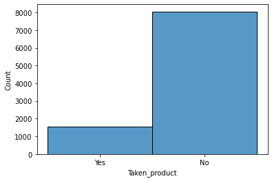

```python
#Taken_product (Whether the user has taken their product or not)

print(data.Taken_product.value_counts())
print('___________')
print(data.Taken_product.value_counts(normalize=True))
sns.histplot(data=data, x="Taken_product")
```

We can see that 84% people did not take the product and only 16% has opted for it.

### For Categorical Variables :

```python
#Pref_device (Preferred device of the user through which user do login)

print(data.Pref_device.value_counts())
```

```
Tab                4172
iOS and Android    2581
Laptop             1108
iOS                 683
Mobile              600
Android             237
Android OS          126
ANDROID              97
Other                 2
Others                1
Name: Pref_device, dtype: int64
```

We can see there are so many devices mentioned in the dataset. But as per the information provided in the problem statement that 'Anything which is not a laptop can be considered as mobile phone usage', so we will replace everything with mobile except Laptop.

```python
data['Pref_device'].replace({'Tab': 'Mobile', 'iOS and Android': 'Mobile', 'iOS': 'Mobile',
                            'Android': 'Mobile', 'Android OS': 'Mobile', 'ANDROID': 'Mobile',
                            'iOS and Android': 'Mobile', 'Other': 'Mobile', 'Others': 'Mobile'}, inplace=True)
```

```
Mobile    8499
Laptop    1108
Name: Pref_device, dtype: int64
___________
Mobile   0.88
Laptop   0.12
Name: Pref_device, dtype: float64
```

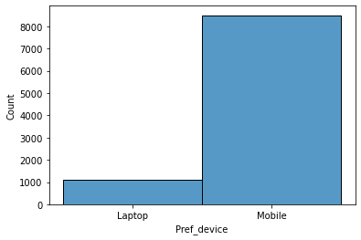

```python
#Now again checking Pref_device column

print(data.Pref_device.value_counts())
print('___________')
print(data.Pref_device.value_counts(normalize=True))
sns.histplot(data=data, x="Pref_device")
```

This indicates that 88% of the people in our data use Mobile as their preferred device.

```python
#Pref_loc_type  (Preferred location type of the user)

print(data.Pref_loc_type.value_counts())
```

```
Beach              2424
Historical site    1856
Financial          1528
Medical            1167
Big Cities          636
Other               535
Trekking            528
Social media        409
Entertainment       313
Hill Stations       108
Tour  Travel         53
Tour and Travel      30
Game                 10
OTT                   6
Movie                 4
Name: Pref_loc_type, dtype: int64
```

We can see that there are various preferred location type available in the data. let us assign few of them into one category and organize these.

1. We will take Beach, Historical site, Trekking, Tour Travel, Tour and Travel and Hill Stations in one category and will name it 'Adventure and Tourism'.
2. We will be replacing Game, OTT, Movie and Social Media with one already available category 'Entertainment'.

```python
data['Pref_loc_type'].replace({'Beach': 'Adventure_and_Tourism',
                               'Historical site': 'Adventure_and_Tourism',
                               'Trekking': 'Adventure_and_Tourism',
                               'Tour  Travel': 'Adventure_and_Tourism',
                               'Tour and Travel': 'Adventure_and_Tourism',
                               'Hill Stations': 'Adventure_and_Tourism',
                               'Game': 'Entertainment',
                               'OTT': 'Entertainment',
                               'Movie': 'Entertainment',
                               'Social media': 'Entertainment',
                               'Big Cities':'Big_Cities'}, inplace=True)
```

```
Adventure_and_Tourism    4999
Financial                1528
Medical                  1167
Entertainment             742
Big_Cities                636
Other                     535
Name: Pref_loc_type, dtype: int64
____________
Adventure_and_Tourism   0.52
Financial               0.16
Medical                 0.12
Entertainment           0.08
Big_Cities              0.07
Other                   0.06
Name: Pref_loc_type, dtype: float64
```

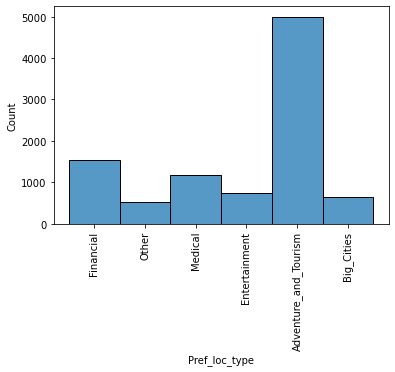

```python
#Checking the updated values and checking the proportion for each

print(data.Pref_loc_type.value_counts())
print('____________')
print(data.Pref_loc_type.value_counts(normalize=True))


#Histogram for pref_loc_type

plt.xticks(rotation=90)
sns.histplot(data=data, x="Pref_loc_type")
```

So after organizing the categories, we found out that 'Adventure and Tourism' is the most preferred location type with 52%. Then 16% of the user has 'Financial' as their preferred location type, because they might travel mostly for business purpose. Then comes the 'Medical' as preferred location, as 12% of the user travel for their medical purposes. Only 8% of the users has 'Entertainment' as their preferred location type.

```python
#Following_CP (whether the user is following the company page or not)

print(data.Following_CP.value_counts())
```

```
No     6900
Yes    2692
1        10
0         5
Name: Following_CP, dtype: int64
```

Here we need the data in the form of 'Yes' and 'No'. So we need to replace numeric value of 1 to Yes and 0 to No.

```python
#replacing 1 and 0 with Yes and No respectively.

data['Following_CP'].replace({'1': 'Yes', '0': 'No'}, inplace=True)
```

```
No     6905
Yes    2702
Name: Following_CP, dtype: int64
_______________
No    0.72
Yes   0.28
Name: Following_CP, dtype: float64
```

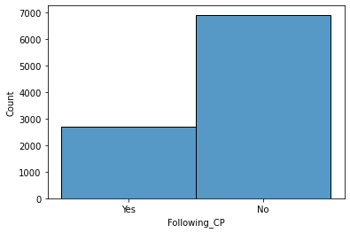

```python
#Again checking

print(data.Following_CP.value_counts())
print('_______________')
print(data.Following_CP.value_counts(normalize = True))

#Histogram for following_CP

sns.histplot(data=data, x="Following_CP")
```

We see that only 28% of the users are following the company page and 72% still do not follow.

```
No     8129
Yes    1478
Name: Working_flag, dtype: int64
___________________
No    0.85
Yes   0.15
Name: Working_flag, dtype: float64
```

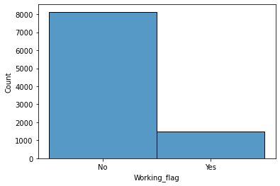

```python
#Working_flag (whether the user is working somewhere or not)

print(data.Working_flag.value_counts())
print('___________________')
print(data.Working_flag.value_counts(normalize = True))

#Histogram for working_flag

sns.histplot(data=data, x="Working_flag")
```

85% of the users do not work anywhere. Only 15% users are working.

```python
#Adult_flag (Whether the user is Adult or not)
#it should be either only 0 and 1, where 0 means user is not adult and 1 means user is adult.

data.Adult_flag.value_counts()
```

```
0    4115
1    3903
2    1026
3     563
Name: Adult_flag, dtype: int64
```

```python
#here we will replace 2 and 3 with 1 because it's a categorical variable which must have only 2 options
#User can either be adult or not, so it should have values of either yes and no, or 1 and 0 and it can't be 2 and 3 in it  .

data['Adult_flag'].replace({2:1, 3:1}, inplace=True)
```

```python
#Now checking again

data.Adult_flag.value_counts()
```

```
1    5492
0    4115
Name: Adult_flag, dtype: int64
```

```python
data['Adult_flag'] = data['Adult_flag'].astype('category')
data.Adult_flag.value_counts(normalize=True)
```

```
1   0.57
0   0.43
Name: Adult_flag, dtype: float64
```

### For Numerical Variables :

```
3     3747
4     2622
2     1829
1     1092
5      307
10      10
Name: Members_in_fam, dtype: int64
_______________
3    0.39
4    0.27
2    0.19
1    0.11
5    0.03
10   0.00
Name: Members_in_fam, dtype: float64
```

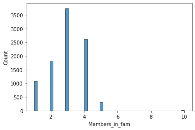

```python
# Members_in_fam (Number of members in the family of the user)

print(data.Members_in_fam.value_counts())
print('_______________')
print(data.Members_in_fam.value_counts(normalize = True))

#Histogram for members_in_fam

sns.histplot(data=data, x="Members_in_fam")
```

Most of the customers have 3 members in their family.

### BIVARIATE ANALYSIS

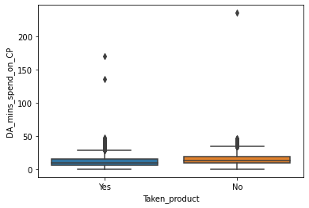

```python
sns.boxplot(x="Taken_product", y="DA_mins_spend_on_CP", data=data)
```

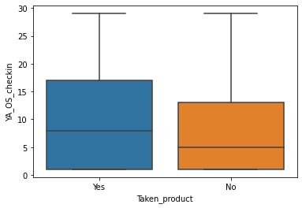

```python
sns.boxplot(x="Taken_product", y="YA_OS_checkin", data=data)
```

The users who has taken the product are having more yearly average out-station check-in than people who did not take the product.

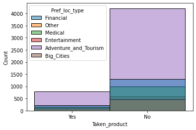

```python
sns.histplot(data=data, x="Taken_product", hue='Pref_loc_type')
```

- Majority of the people has not taken the product, but preferred 'Adventure and Tourism' kind of locations to visit, that means that users have taken the product from some other company.
- Also, the users who took the product chose 'Adventure and Tourism' kind of locations to visit.

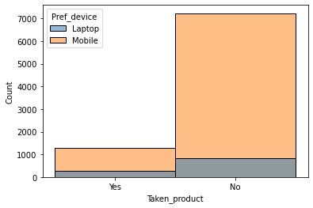

```python
sns.histplot(data=data, x="Taken_product", hue='Pref_device')
```

### Detecting and Treating the Outliers :-

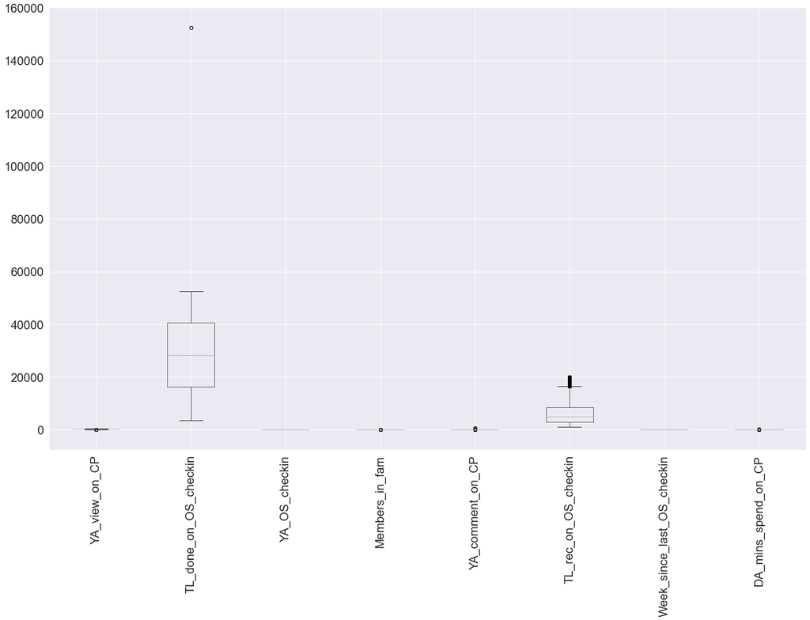

```python
#Detecting Outliers by making a box plot for numerical attributes

num_columns = ['YA_view_on_CP' ,'TL_done_on_OS_checkin', 'YA_OS_checkin', 'Members_in_fam', 'YA_comment_on_CP',
               'TL_rec_on_OS_checkin','Week_since_last_OS_checkin','DA_mins_spend_on_CP']

sns.set(font_scale = 2)
data[num_columns].boxplot(figsize=(25, 15), rot=90)
```

There are few outliers in the data.

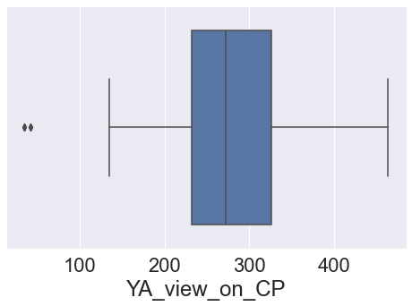

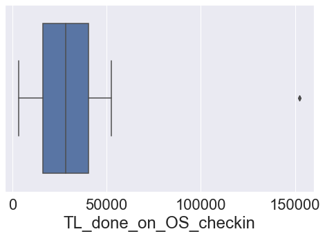

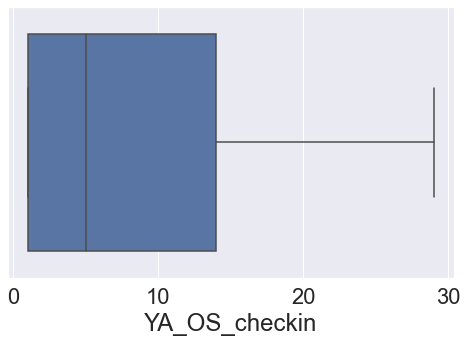

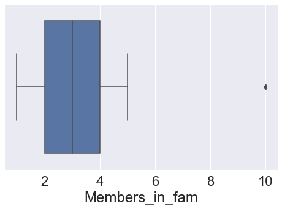

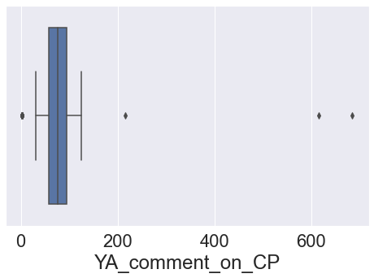

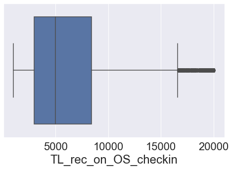

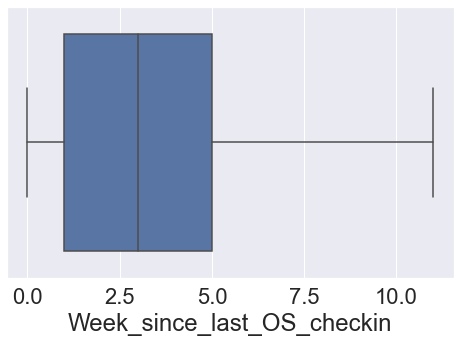

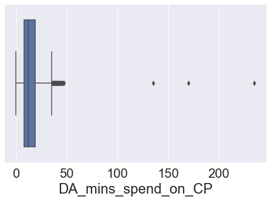

```python
#let us look at them one by one for each numerical variables

for col in num_columns:
    plt.figure(figsize=(8,5))
    sns.boxplot(data[col])
    plt.show()
```

```python
# Let see the description once again

data.describe().T
```

|  | count | mean | std | min | 25% | 50% | 75% | max |
| --- | --- | --- | --- | --- | --- | --- | --- | --- |
| YA_view_on_CP | 9607.00 | 281.99 | 68.50 | 35.00 | 232.00 | 272.00 | 326.00 | 464.00 |
| TL_done_on_OS_checkin | 9607.00 | 28171.22 | 14230.24 | 3570.00 | 16312.50 | 28178.00 | 40542.50 | 152465.00 |
| YA_OS_checkin | 9607.00 | 8.40 | 8.54 | 1.00 | 1.00 | 5.00 | 14.00 | 29.00 |
| Members_in_fam | 9607.00 | 2.93 | 1.04 | 1.00 | 2.00 | 3.00 | 4.00 | 10.00 |
| YA_comment_on_CP | 9607.00 | 76.03 | 23.16 | 3.00 | 58.00 | 76.00 | 94.00 | 685.00 |
| TL_rec_on_OS_checkin | 9607.00 | 6542.95 | 4712.54 | 1009.00 | 2952.50 | 4955.00 | 8412.00 | 20065.00 |
| Week_since_last_OS_checkin | 9607.00 | 3.26 | 2.62 | 0.00 | 1.00 | 3.00 | 5.00 | 11.00 |
| DA_mins_spend_on_CP | 9607.00 | 14.08 | 8.88 | 0.00 | 8.00 | 12.00 | 19.00 | 235.00 |

### Identifying Outliers with Interquartile Range :-

The interquartile range (IQR) is a measure of statistical dispersion and is calculated as the difference between the 75th and 25th percentiles. It is represented by the formula IQR = Q3 − Q1.

```python
#Calculating Q1, Q3 and IQR values and assigning the upper limit (UL) and lower limit (LL)

Q1 = data[num_columns].quantile(0.25)
Q3 = data[num_columns].quantile(0.75)
IQR = Q3 - Q1
UL = Q3 + 1.5*IQR
LL = Q1 - 1.5*IQR
```

```python
print('IQR values (Q3-Q1):\n\n',IQR)
print('\n_______________________\n')
print('Upper Limit (Q3 + 1.5*IQR):\n\n',UL)
print('_______________________')
print('Lower Limit (Q1 - 1.5*IQR):\n\n',LL)
```

```
IQR values (Q3-Q1):

 YA_view_on_CP                   94.00
TL_done_on_OS_checkin        24230.00
YA_OS_checkin                   13.00
Members_in_fam                   2.00
YA_comment_on_CP                36.00
TL_rec_on_OS_checkin          5459.50
Week_since_last_OS_checkin       4.00
DA_mins_spend_on_CP             11.00
dtype: float64

_______________________

Upper Limit (Q3 + 1.5*IQR):

 YA_view_on_CP                  467.00
TL_done_on_OS_checkin        76887.50
YA_OS_checkin                   33.50
Members_in_fam                   7.00
YA_comment_on_CP               148.00
TL_rec_on_OS_checkin         16601.25
Week_since_last_OS_checkin      11.00
DA_mins_spend_on_CP             35.50
dtype: float64
_______________________
Lower Limit (Q1 - 1.5*IQR):

 YA_view_on_CP                    91.00
TL_done_on_OS_checkin        -20032.50
YA_OS_checkin                   -18.50
Members_in_fam                   -1.00
YA_comment_on_CP                  4.00
TL_rec_on_OS_checkin          -5236.75
Week_since_last_OS_checkin       -5.00
DA_mins_spend_on_CP              -8.50
dtype: float64
```

```python
#Now, according to the above scores/values, checking the number of outliers present in each column

pd.options.display.max_rows = None
((data[num_columns] > UL) | (data[num_columns] < LL)).sum()
```

```
YA_view_on_CP                   8
TL_done_on_OS_checkin           2
YA_OS_checkin                   0
Members_in_fam                 10
YA_comment_on_CP               21
TL_rec_on_OS_checkin          752
Week_since_last_OS_checkin      0
DA_mins_spend_on_CP           210
dtype: int64
```

```python
#Total sum of outliers

print('Total number of outliers in the dataset:',((data[num_columns] > UL) | (data[num_columns] < LL)).sum().sum())
```

```
Total number of outliers in the dataset: 1003
```

### Identifying Outliers with Skewness and Distribution Plot :-

Several machine learning algorithms make the assumption that the data follow a normal (or Gaussian) distribution. This is easy to check with the skewness value, which explains the extent to which the data is normally distributed. Ideally, the skewness value should be between -1 and +1, and any major deviation from this range indicates the presence of extreme values.

The rule of thumb seems to be: If the skewness is between -0.5 and 0.5, the data are fairly symmetrical. If the skewness is between -1 and – 0.5 or between 0.5 and 1, the data are moderately skewed. If the skewness is less than -1 or greater than 1, the data are highly skewed.

```python
print(data[num_columns].skew())
```

```
YA_view_on_CP                0.40
TL_done_on_OS_checkin        0.12
YA_OS_checkin                0.96
Members_in_fam               0.02
YA_comment_on_CP             3.16
TL_rec_on_OS_checkin         1.37
Week_since_last_OS_checkin   0.91
DA_mins_spend_on_CP          3.17
dtype: float64
```

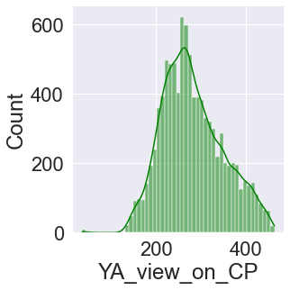

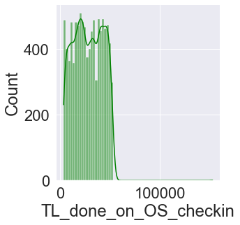

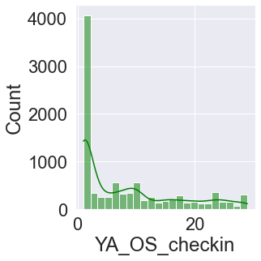

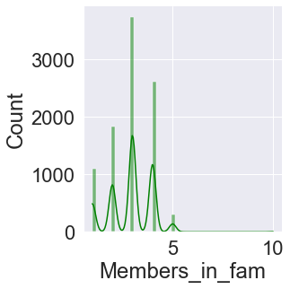

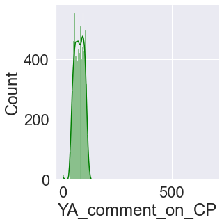

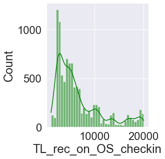

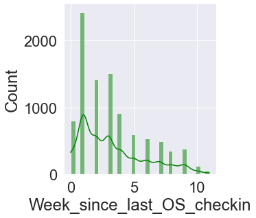

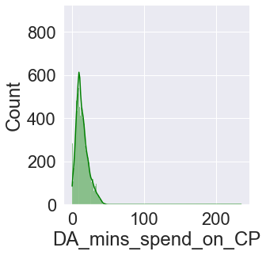

```python
for x in num_columns:
    plt.figure(figsize=(10,8))
    sns.displot(data[x], kde=True, color='green')
    plt.show()
```